# Students Data Analysis

Hasibullah Mahmood

April 2, 2020

## Import the relevant libraries

```r
library(ggplot2)
library(gridExtra)
```

## Load the data

```r
students <- read.csv("students.csv")
attach(students)
head(students)
```

```
##   stud.id                name gender age height weight   religion nc.score
## 1  833917 Gonzales, Christina Female  19    160   64.8     Muslim     1.91
## 2  898539      Lozano, T'Hani Female  19    172   73.0      Other     1.56
## 3  379678      Williams, Hanh Female  22    168   70.6 Protestant     1.24
## 4  807564         Nem, Denzel   Male  19    183   79.7      Other     1.37
## 5  383291     Powell, Heather Female  21    175   71.4   Catholic     1.46
## 6  256074      Perez, Jadrian   Male  19    189   85.8   Catholic     1.34
##   semester                  major                      minor score1 score2
## 1      1st      Political Science            Social Sciences     NA     NA
## 2      2nd        Social Sciences Mathematics and Statistics     NA     NA
## 3      3rd        Social Sciences Mathematics and Statistics     45     46
## 4      2nd Environmental Sciences Mathematics and Statistics     NA     NA
## 5      1st Environmental Sciences Mathematics and Statistics     NA     NA
## 6      2nd      Political Science Mathematics and Statistics     NA     NA
##   online.tutorial graduated salary
## 1               0         0     NA
## 2               0         0     NA
## 3               0         0     NA
## 4               0         0     NA
## 5               0         0     NA
## 6               0         0     NA
```

## Some basic analysis

```r
cat("Total number of Variables:", length(students),
    "\nTotal number of students:", length(stud.id))
```

```
## Total number of Variables: 16
## Total number of students: 8239
```

#### Checking summary of gender

```r
summary(gender)
```

```
## Female   Male
##   4110   4129
```

#### Analyzing Students Age

```r
summary(age)
```

```
##    Min. 1st Qu.  Median    Mean 3rd Qu.    Max.
##   18.00   20.00   21.00   22.54   23.00   64.00
```

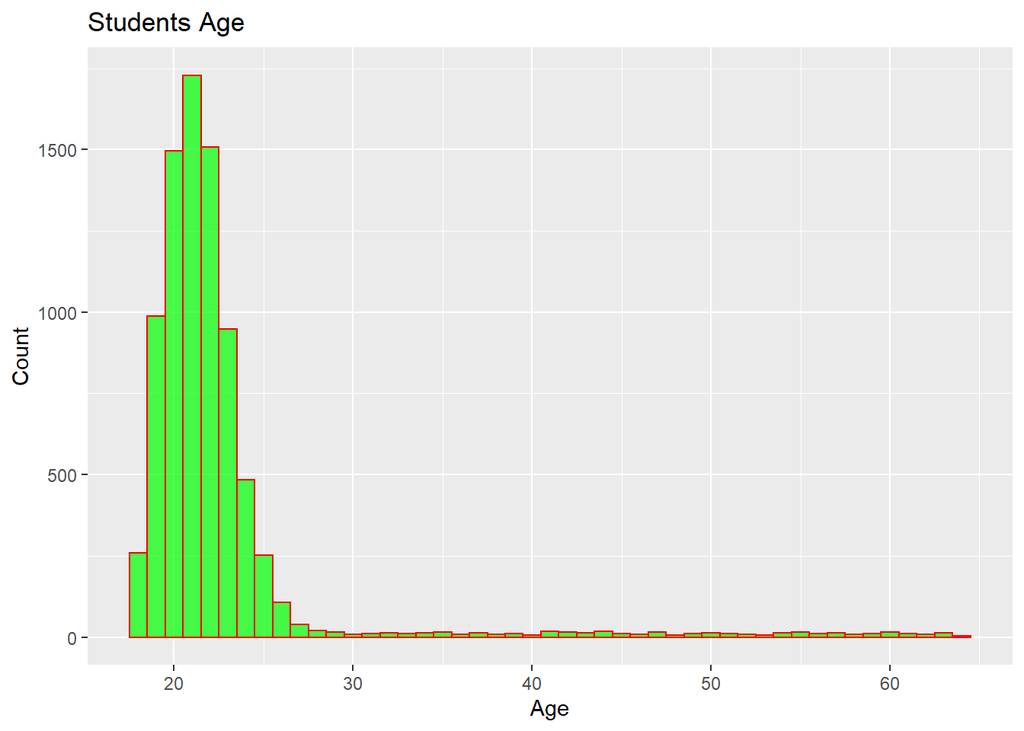

```r
ggplot(data=students, aes(x=students$age)) +
  geom_histogram(binwidth=1, col="red", fill="green", alpha=0.7)+
  labs(title = "Students Age", x="Age", y="Count")
```

The above figure shows most of students are between 18-25 years old.

#### Analyzing Students Height

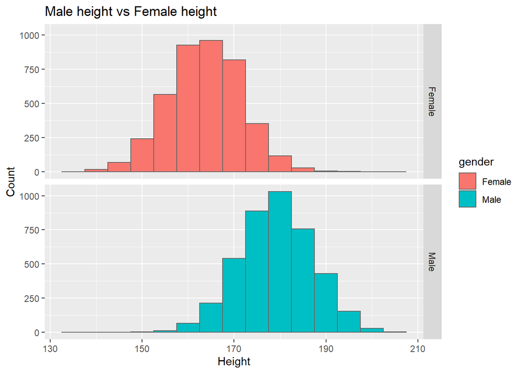

```r
ggplot(students, aes(students$height, fill=gender)) +
  geom_histogram(position="identity", colour="grey40", binwidth=5) +
  facet_grid(gender ~ .) +
  ggtitle("Male height vs Female height") +
  xlab("Height") +
  ylab("Count")
```

Students height looks to be symmetric normal distribution, but in order to be sure enough we will use qqnorm and qqline functions.

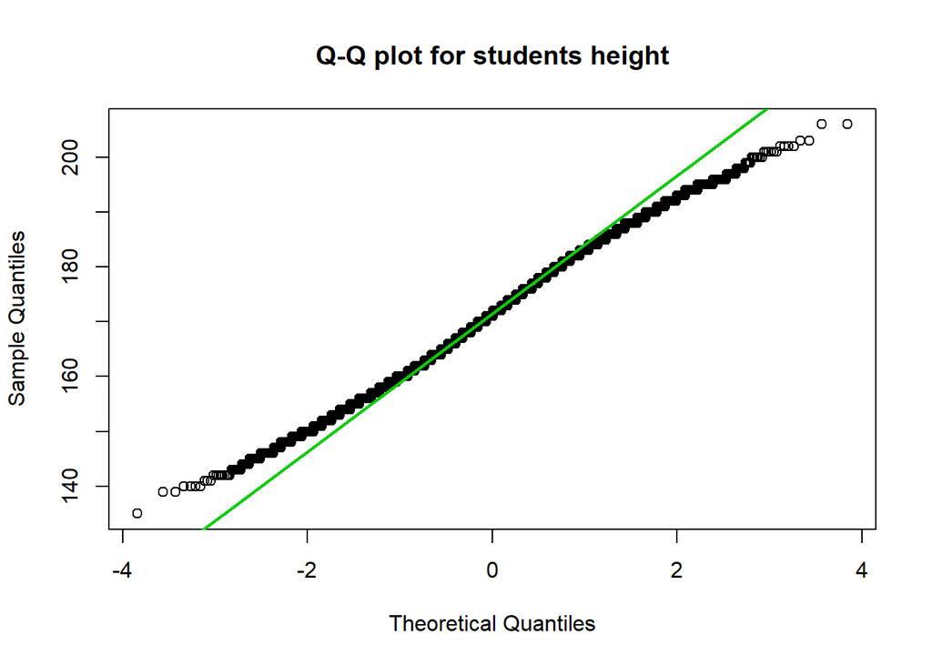

```r
qqnorm(students$height, main="Q-Q plot for students height")
qqline(students$height, col=3, lwd=2)
```

By examining the plot we can see there is divergence in upper tail and lower tail of the graph, so we will examine it further by taking the subset of data in to male and female.

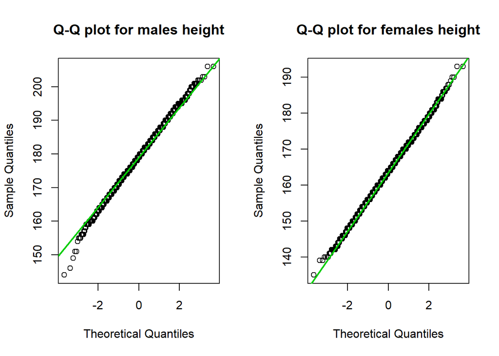

```r
males <- subset(students, gender=="Male")
females <- subset(students, gender=="Female")
par(mfrow=c(1, 2))
qqnorm(males$height, main="Q-Q plot for males height")
qqline(males$height, col=3, lwd=2)

qqnorm(females$height, main="Q-Q plot for females height")
qqline(females$height, col=3, lwd=2)
```

Now we are sure that the height of male and female students are symmetric normal distribution, for better understanding We will have a look at summary and the standard deviation of student’s heights.

```r
summary(males$height)
```

```
##    Min. 1st Qu.  Median    Mean 3rd Qu.    Max.
##   144.0   174.0   179.0   179.1   184.0   206.0
```

```r
sd(males$height)
```

```
## [1] 7.988852
```

```r
summary(females$height)
```

```
##    Min. 1st Qu.  Median    Mean 3rd Qu.    Max.
##   135.0   158.0   164.0   163.7   169.0   193.0
```

```r
sd(females$height)
```

```
## [1] 7.919726
```

We can use boxplot in order to check if there is any outlier or not.

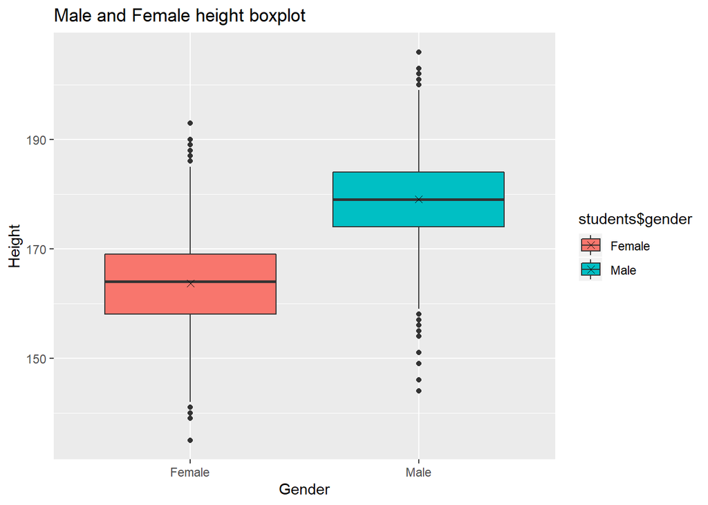

```r
ggplot(data=students, aes(x=students$gender, y=students$height, fill=students$gender)) +
  geom_boxplot() +
  labs(title = "Male and Female height boxplot", x = "Gender", y="Height") +
  stat_summary(fun.y=mean, geom="point", shape=4, size=2)
```

The above boxplot shows there are outliers both in male and female students height.

#### Analyzing Students Weight

```r
summary(males$weight)
```

```
##    Min. 1st Qu.  Median    Mean 3rd Qu.    Max.
##   56.90   73.20   77.90   78.59   83.20  116.00
```

```r
summary(females$weight)
```

```
##    Min. 1st Qu.  Median    Mean 3rd Qu.    Max.
##   51.40   63.70   67.00   67.38   70.60   93.80
```

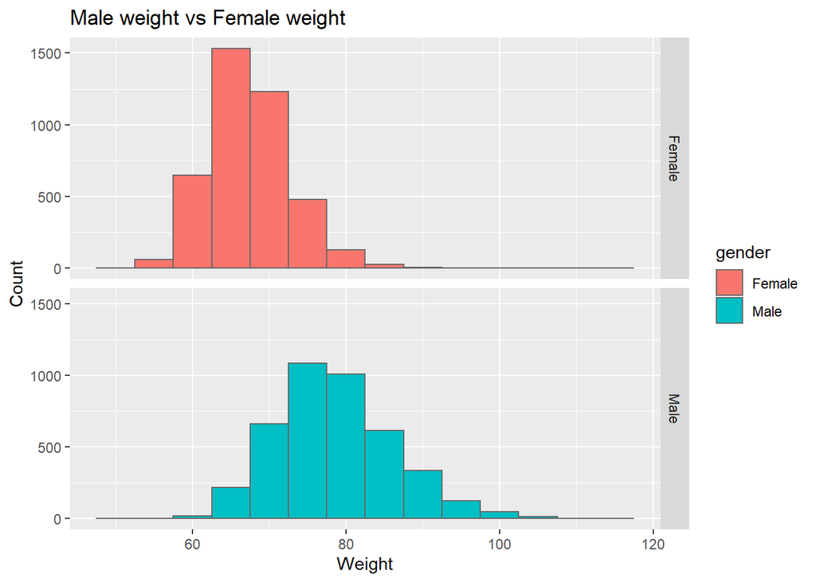

```r
ggplot(students, aes(students$weight, fill=gender)) +
  geom_histogram(position="identity", colour="grey40", binwidth=5) +
  facet_grid(gender ~ .) +
  ggtitle("Male weight vs Female weight") +
  xlab("Weight") +
  ylab("Count")
```

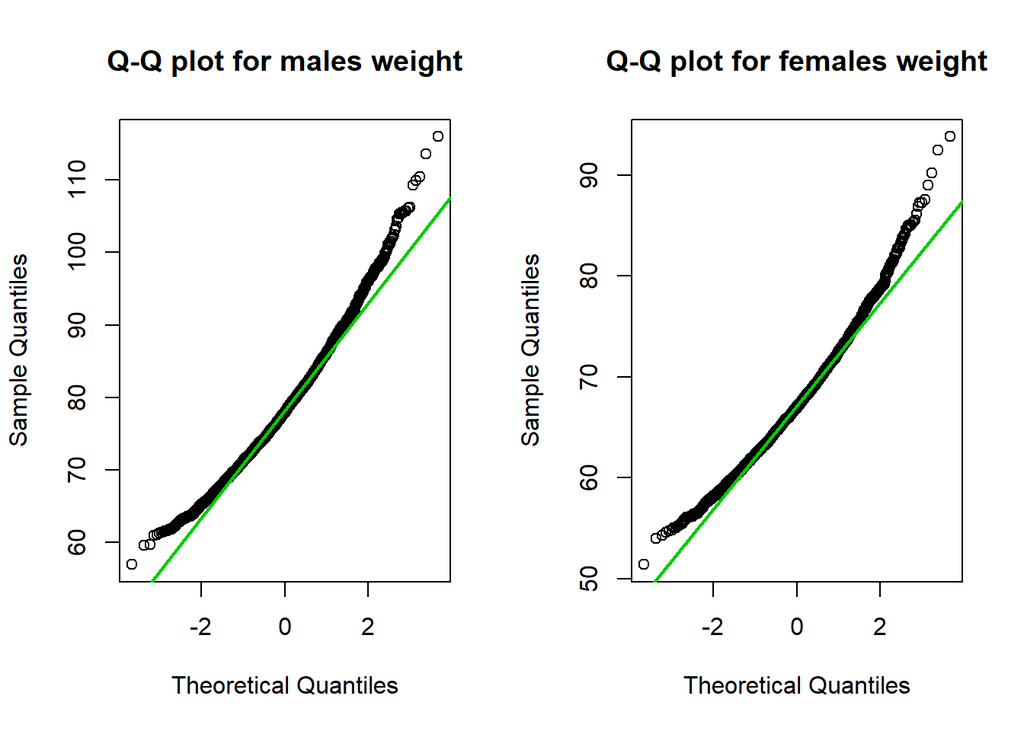

```r
par(mfrow=c(1, 2))
qqnorm(males$weight, main="Q-Q plot for males weight")
qqline(males$weight, col=3, lwd=2)

qqnorm(females$weight, main="Q-Q plot for females weight")
qqline(females$weight, col=3, lwd=2)
```

#### Analyzing student’s religion

```r
summary(religion)
```

```
##   Catholic     Muslim   Orthodox      Other Protestant
##       2797        330        585       2688       1839
```

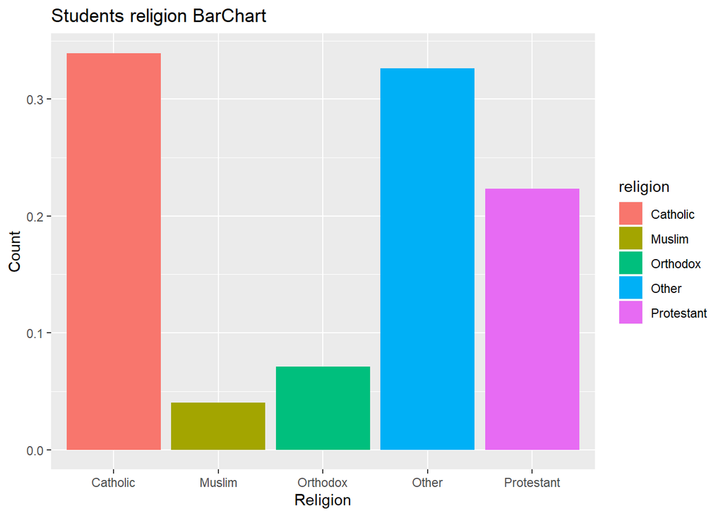

```r
ggplot(students, aes(x=religion, fill=religion))+
  geom_bar(aes(y = (..count..)/sum(..count..))) +
  labs(title = "Students religion BarChart",x= "Religion",y= "Count")
```

Catholic religion has the most followers between students.

#### Analyzing student’s nc.Score

```r
summary(nc.score)
```

```
##    Min. 1st Qu.  Median    Mean 3rd Qu.    Max.
##   1.000   1.460   2.040   2.166   2.780   4.000
```

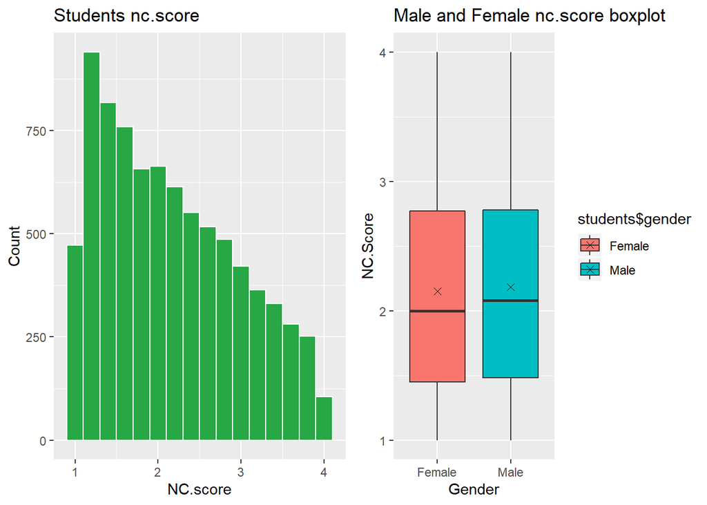

```r
plot1 <- ggplot(students, aes(x=nc.score)) +
  geom_histogram(binwidth = 0.2, colour="white", fill="#28a745") +
  labs(title = "Students nc.score", x="NC.score", y="Count")

plot2 <- ggplot(data=students, aes(x=students$gender, y=students$nc.score, fill=students$gender)) +
  geom_boxplot() +
  labs(title = "Male and Female nc.score boxplot", x = "Gender", y="NC.Score") +
  stat_summary(fun.y=mean, geom="point", shape=4, size=2)

grid.arrange(plot1, plot2, ncol=2)
```

Students nc.score is asymmetric and skewed to the right

#### Analyzing student’s Semester

```r
summary(semester)
```

```
## >6th  1st  2nd  3rd  4th  5th  6th
##  303 1709 1638 1641 1368  876  704
```

The summary of semester shows there is a problem in data, the 6th semester is written in two ways “>6th” and “6th”.  
The problem can be solved by the following code:

```r
students$semester[students$semester == ">6th"] <- "6th"
summary(students$semester)
```

```
## >6th  1st  2nd  3rd  4th  5th  6th
##    0 1709 1638 1641 1368  876 1007
```

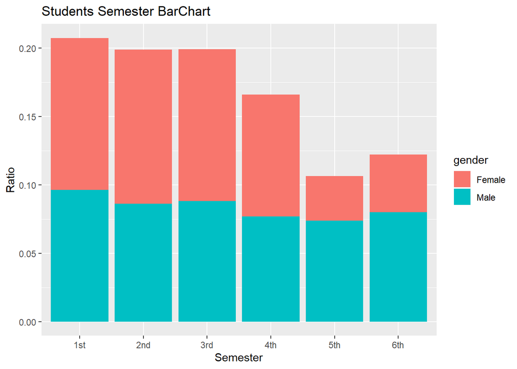

```r
ggplot(students, aes(x=semester, fill=gender))+
  geom_bar(aes(y = (..count..)/sum(..count..))) +
  labs(title = "Students Semester BarChart",x= "Semester",y= "Ratio")
```

The above Barchart shows more than 60% of students are in 1st, 2nd and 3rd semesters.

#### Analyzing student’s Major

```r
summary(students$major)
```

```
##                    Biology      Economics and Finance
##                       1597                       1324
##     Environmental Sciences Mathematics and Statistics
##                       1626                       1225
##          Political Science            Social Sciences
##                       1455                       1012
```

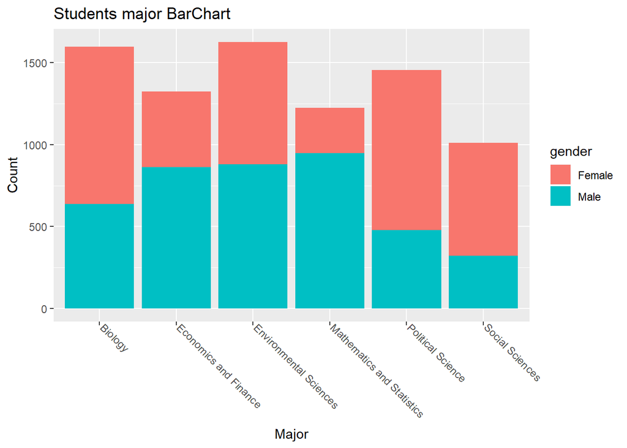

```r
ggplot(students, aes(x=major, fill=gender))+
  geom_bar() +
  labs(title = "Students major BarChart",x= "Major",y= "Count") +
  theme(axis.text.x=element_text(angle=-45,hjust=0,vjust=0))
```

From above graph one can easily conclude that Environmental science and Biology faculties have the most students among other, also females are more than males in Biology and Political science faculties and males are more than females in ‘Economics and Finance’ and ‘Mathematics and statistics’ faculties and …

#### Analyzing student’s Minor

```r
summary(students$minor)
```

```
##                    Biology      Economics and Finance
##                       1318                       1382
##     Environmental Sciences Mathematics and Statistics
##                       1318                       1446
##          Political Science            Social Sciences
##                       1387                       1388
```

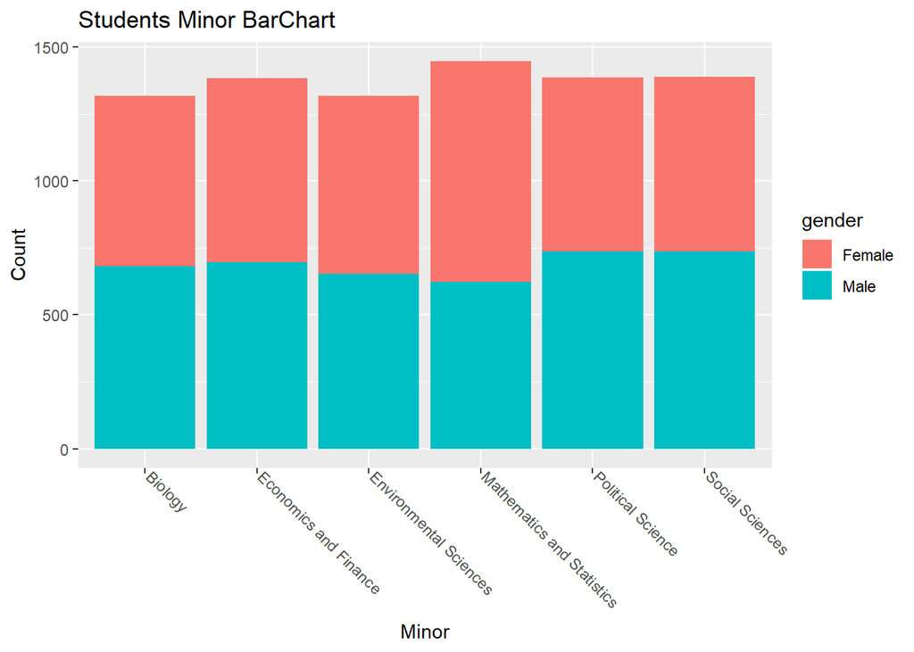

```r
ggplot(students, aes(x=minor, fill=gender))+
  geom_bar() +
  labs(title = "Students Minor BarChart",x= "Minor",y= "Count") +
  theme(axis.text.x=element_text(angle=-45,hjust=0,vjust=0))
```

The above Barchart shows Students are uniformly distributed.

#### Analyzing student’s Score1

```r
summary(students$score1)
```

```
##    Min. 1st Qu.  Median    Mean 3rd Qu.    Max.    NA's
##   30.00   58.00   70.00   68.17   78.00   97.00    3347
```

The above summary shows there are 3347 Empty cells for score1. Therefore, I will take subset of students based on their major for better analyzing.

```r
students.math <- subset(students, major=="Mathematics and Statistics")
cat("Number of students in Mathematics and Statistics faculty:",length(students.math[,1]))
```

```
## Number of students in Mathematics and Statistics faculty: 1225
```

```r
cat("Number of students who do not have score1:",length(students.math$score1[is.na(students.math$score1)]))
```

```
## Number of students who do not have score1: 478
```

```r
cat("Number of students who have score1:",length(students.math$score1[!is.na(students.math$score1)]))
```

```
## Number of students who have score1: 747
```

```r
summary(students.math$score1)
```

```
##    Min. 1st Qu.  Median    Mean 3rd Qu.    Max.    NA's
##   78.00   86.00   88.00   88.09   90.00   97.00     478
```

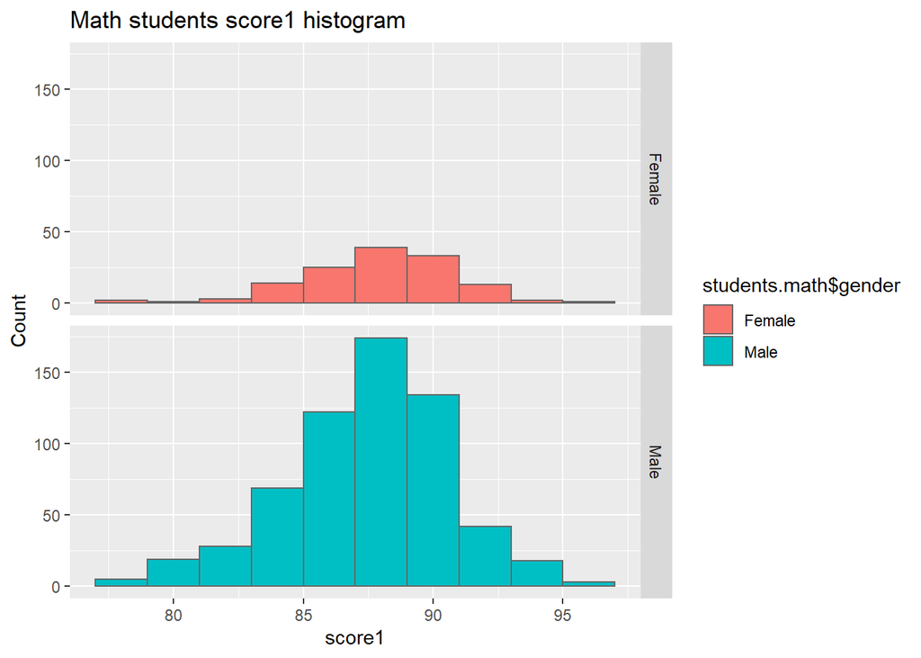

```r
ggplot(students.math, aes(students.math$score1, fill=students.math$gender)) +
  geom_histogram(position="identity", colour="grey40", binwidth=2) +
  facet_grid(students.math$gender ~ .)+
  labs(title="Math students score1 histogram", x ="score1", y="Count")
```

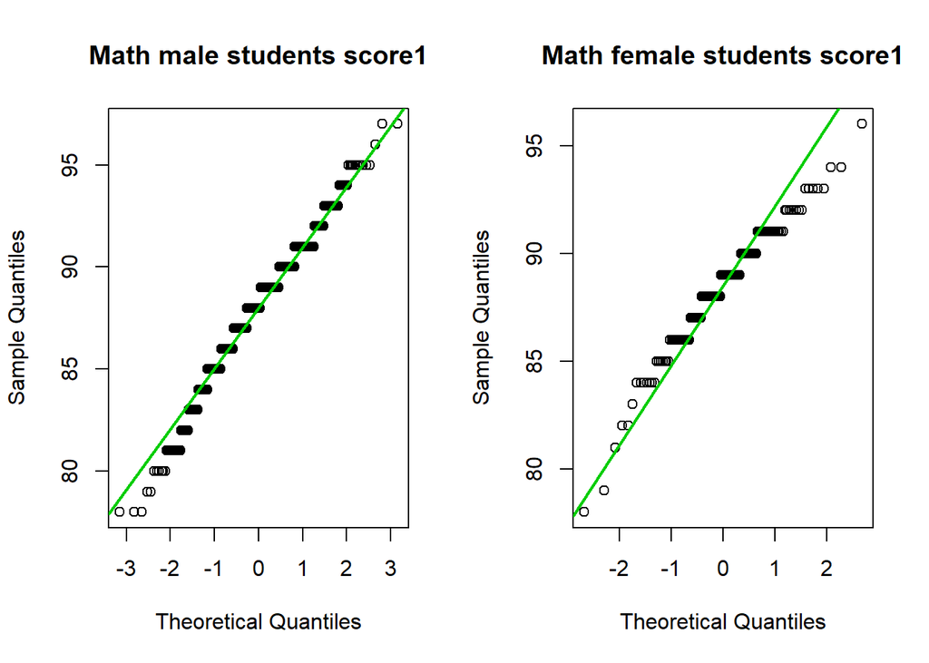

```r
par(mfrow=c(1, 2))
qqnorm(students.math$score1[students.math$gender=="Male"],
       main="Math male students score1")
qqline(students.math$score1[students.math$gender=="Male"], col=3, lwd=2)

qqnorm(students.math$score1[students.math$gender=="Female"],
       main="Math female students score1")
qqline(students.math$score1[students.math$gender=="Female"], col=3, lwd=2)
```

The above histogram and Q-Q plot shows students score1 is roughly symmetric and great portion of student’s score1 lies between 83-91.

#### Analyzing student’s graduated variable

```r
table(graduated)
```

```
## graduated
##    0    1
## 6486 1753
```

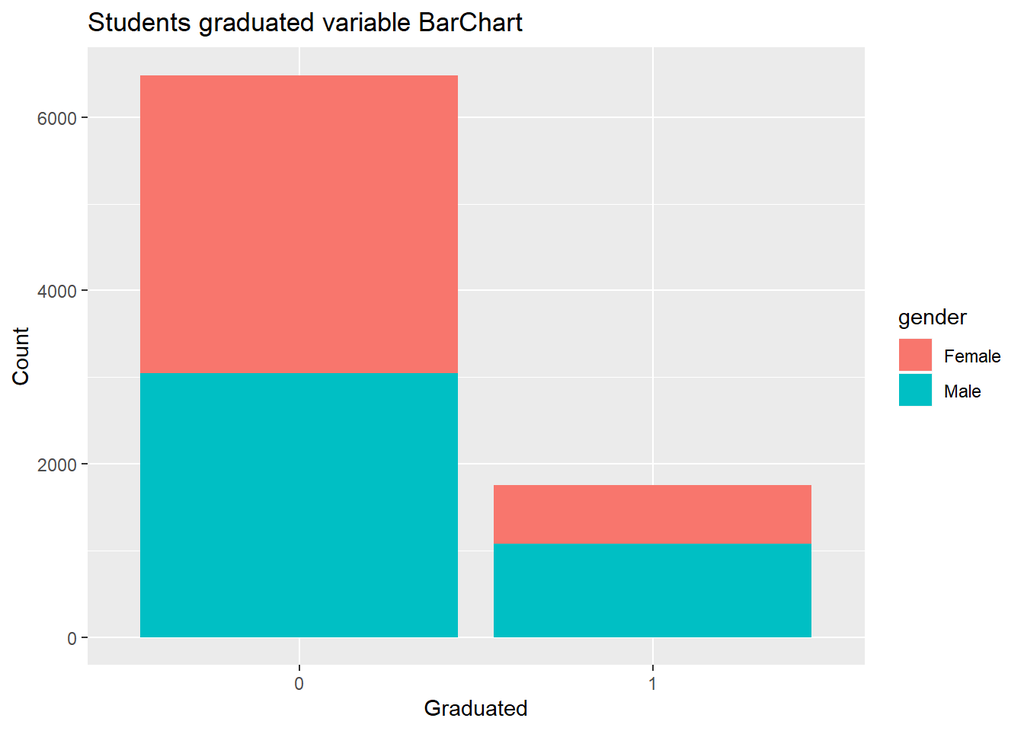

```r
ggplot(students, aes(x=as.factor(graduated), fill=gender))+
  geom_bar() +
  labs(title = "Students graduated variable BarChart",x= "Graduated",y= "Count")
```

The above Barchart shows most of graduated students are male and most of students who are still studying are females.

#### Analyzing student’s Salary Variable

```r
summary(salary)
```

```
##    Min. 1st Qu.  Median    Mean 3rd Qu.    Max.    NA's
##   11444   35207   41672   42522   49373   75597    6486
```

The summary shows there are 6486 rows in Salary variable which are empty. I will take the subset of students who have salary and I will plot the histogram, density histogram and qqplot of salary for further analyzing.

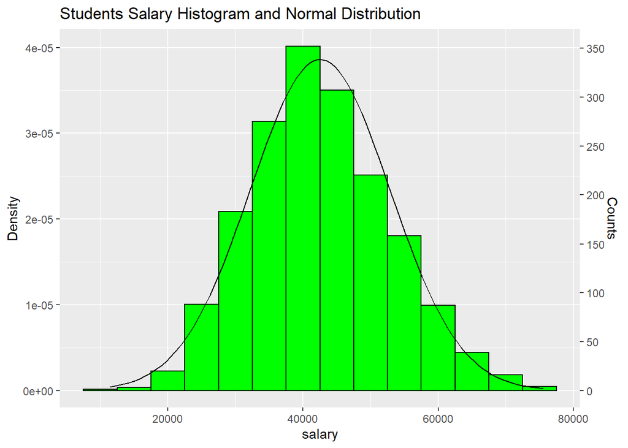

```r
students.salary <- students[!is.na(students$salary),]

# Set desired binwidth and number of non-missing obs
bw = 5000
n_obs = sum(!is.na(students.salary$salary))

g <- ggplot(students.salary, aes(x=salary)) +
  geom_histogram(aes(y=..density..), binwidth = bw, colour="black", fill="green")+
  stat_function(fun=dnorm, args = list(mean = mean(students.salary$salary), sd = sd(students.salary$salary))) +
  ggtitle("Students Salary Histogram and Normal Distribution")


ybreaks = seq(0,350,50)

## On primary axis and secondary axix
g + scale_y_continuous("Counts", breaks = round(ybreaks / (bw * n_obs),3), labels = ybreaks) +
  scale_y_continuous("Density", sec.axis = sec_axis(
  trans = ~ . * bw * n_obs, name = "Counts", breaks = ybreaks))
```

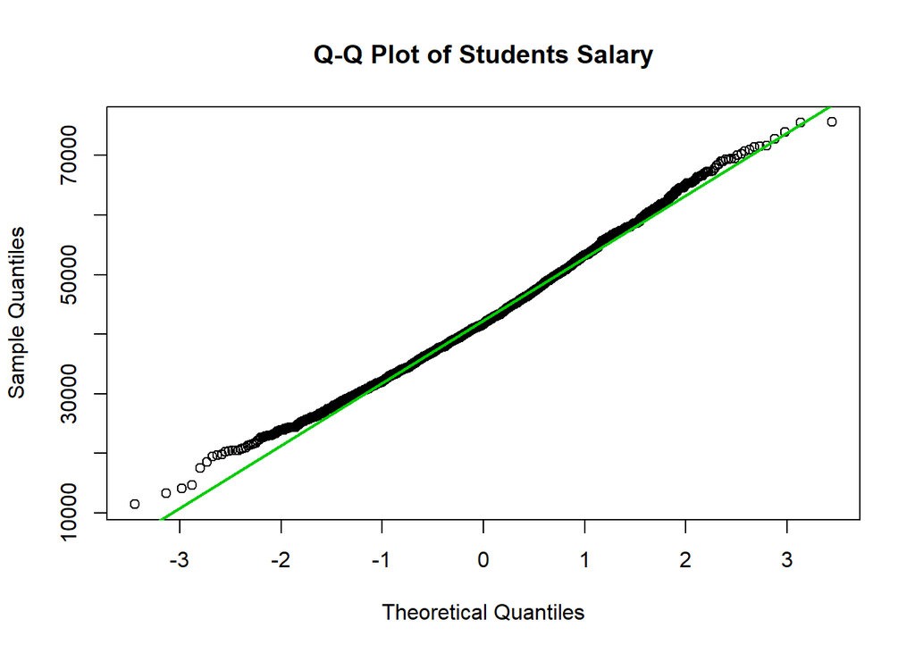

```r
qqnorm(students.salary$salary, main = "Q-Q Plot of Students Salary")
qqline(students.salary$salary, col=3, lwd=2)
```

#### Analyzing correlation between Student’s n.score and salary

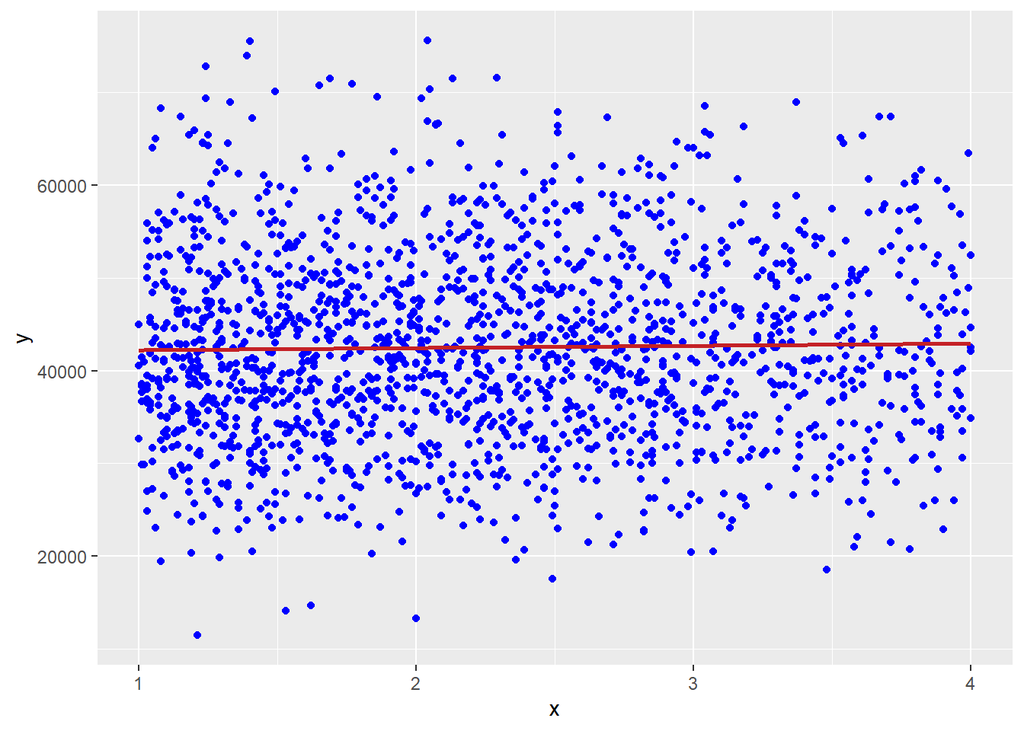

```
##  The Correlation Coefficient:  0.0189558417515911
##  Evaluation Result:  Weak Positive Relationship
```

```r
# define function
correlation.analyzer <- function(data, x, y) {
  print(
    ggplot(data = data, aes(x = x, y = y)) +
      geom_point(color = 'blue') +
      geom_smooth(
        method = lm,
        se
        = FALSE,
        fullrange = TRUE,
        col = "#C42126"
      )
  )

  cor.val <- cor(x, y, method = 'pearson')
  if (cor.val > 0.7) {
    result <- "Strong Positive Relationship"
  } else if (cor.val > 0.3) {
    result <- "Moderate Positive Relationship"
  } else if (cor.val > 0) {
    result <- "Weak Positive Relationship"
  } else if (cor.val > -0.3) {
    result <- "Weak Negative Relationship"
  } else if (cor.val > -0.7) {
    result <- "Moderate Negative Relationship"
  } else if (cor.val >= -1) {
    result <- "Strong Negative Relationship"
  }
  return(cat(
    paste(
      " The Correlation Coefficient: ",
      cor.val,
      "\n",
      "Evaluation Result: ",
      result,
      "\n",
      sep = " "
    )
  ))
}


correlation.analyzer(students.salary,
                     students.salary$nc.score,
                     students.salary$salary
                     )
```

The figure shows there is no correlation between students n.score and salary.

#### Analyzing correlation between Student’s score1 and salary

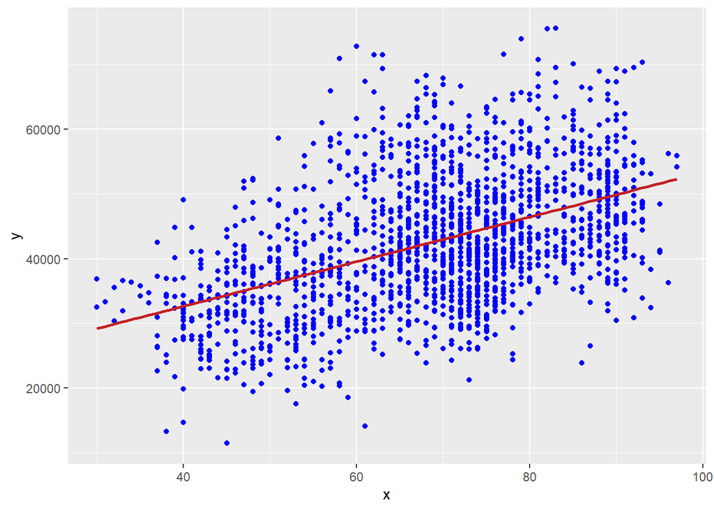

```
##  The Correlation Coefficient:  0.470997361701785
##  Evaluation Result:  Moderate Positive Relationship
```

```r
correlation.analyzer(students.salary,
                     students.salary$score1,
                     students.salary$salary
                     )
```

#### Analyzing correlation between Student’s score2 and salary

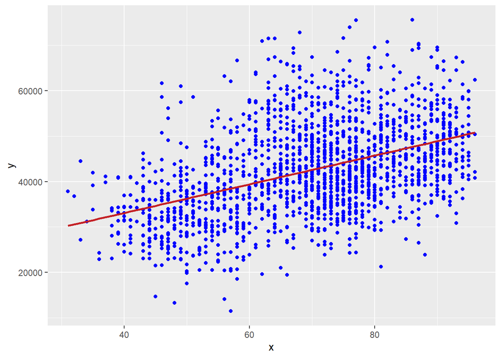

```
##  The Correlation Coefficient:  0.440388281182651
##  Evaluation Result:  Moderate Positive Relationship
```

```r
correlation.analyzer(students.salary,
                     students.salary$score2,
                     students.salary$salary
                     )
```